# TUM DUMM

## Introdução

Aqui está uma análise dos dados de filmes e séries da netflix, disponíveis no kaggle em (https://www.kaggle.com/shivamb/netflix-shows).

- Por **Arthur Rocha** - 2021-03-31

## Libs

```r
library(rmarkdown)
library(tidyverse) #meta-lib com libs dos deuses
library(scales) #escalas
library(arules) # regras de associacao
library(cluster)
library(igraph)
library(networkD3)
```

```r
# funcao para tabela sair em html
tb_bm <- function(tb){
   knitr::kable(tb,
                format.args = list(decimal.mark = ",", big.mark = "."))
}

tema_netflix <-
   theme_light() +
   theme(strip.background = element_rect(fill = "#434139"))
```

## Dados

- Os dados possuem 7.787 linhas e 12 colunas.

```r
netflix <- read_csv("netflix_titles.csv")
```

```r
netflix %>%
  glimpse()
```

```
## Rows: 7,787
## Columns: 12
## $ show_id      <chr> "s1", "s2", "s3", "s4", "s5", "s6", "s7", "s8", "s9", "s…
## $ type         <chr> "TV Show", "Movie", "Movie", "Movie", "Movie", "TV Show"…
## $ title        <chr> "3%", "7:19", "23:59", "9", "21", "46", "122", "187", "7…
## $ director     <chr> NA, "Jorge Michel Grau", "Gilbert Chan", "Shane Acker", …
## $ cast         <chr> "João Miguel, Bianca Comparato, Michel Gomes, Rodolfo Va…
## $ country      <chr> "Brazil", "Mexico", "Singapore", "United States", "Unite…
## $ date_added   <chr> "August 14, 2020", "December 23, 2016", "December 20, 20…
## $ release_year <dbl> 2020, 2016, 2011, 2009, 2008, 2016, 2019, 1997, 2019, 20…
## $ rating       <chr> "TV-MA", "TV-MA", "R", "PG-13", "PG-13", "TV-MA", "TV-MA…
## $ duration     <chr> "4 Seasons", "93 min", "78 min", "80 min", "123 min", "1…
## $ listed_in    <chr> "International TV Shows, TV Dramas, TV Sci-Fi & Fantasy"…
## $ description  <chr> "In a future where the elite inhabit an island paradise …
```

## Análise

### Filme x Série

- 69% do catálogo é formado por filmes e 31% por Séries (TV Shows).

```r
netflix %>%
   count(type, sort = T) %>%
   mutate(pct = percent(n/sum(n))) %>%
   tb_bm()
```

| type | n | pct |
| --- | --- | --- |
| Movie | 5.377 | 69% |
| TV Show | 2.410 | 31% |

### Ano de lançamento

- No dataset temos filmes datados de 1942 a 2021 e shows de tv entre 1925 até 2021.

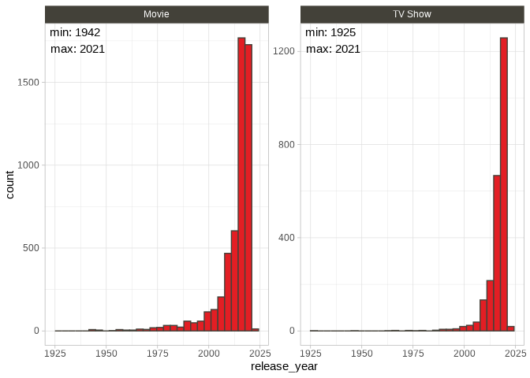

```r
netflix %>%
   group_by(type) %>%
   mutate(lab = paste0("min: ", min(release_year),
                       "\n", "max: ", max(release_year))) %>%
   ggplot(aes(release_year)) +
   geom_histogram(fill = "#e31e24", col = "#434139") +
   facet_wrap(~type, scales = "free_y") +
   geom_text(aes(label = lab,  x = -Inf, y = Inf),
             hjust = -0.1, vjust = 1.2, check_overlap = T) +
   tema_netflix
```

### Duração

- A maior parte das séries de TV tem duração de 1 temporada e o tempo médio de duração dos filmes no catálogo é de aproximadamente 99 minutos.

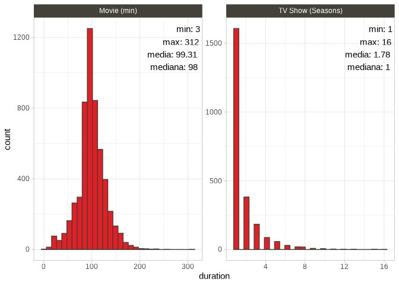

```r
netflix %>%
   mutate(duration = str_remove_all(duration, " Seasons| Season| min"),
          duration = as.numeric(duration)) %>%
   select(type, duration) %>%
   mutate(type = ifelse(type == "Movie", "Movie (min)", "TV Show (Seasons)")) %>%
   group_by(type) %>%
   mutate(lab = paste0("min: ", min(duration),
                       "\n", "max: ", max(duration),
                       "\n", "media: ", round(mean(duration),2),
                       "\n", "mediana: ", median(duration))) %>%
   ggplot(aes(duration)) +
   geom_histogram(fill = "#e31e24", col = "#434139") +
   facet_wrap(~type, scales = "free") +
   geom_text(aes(label = lab,  x = Inf, y = Inf),
             hjust = 1.1, vjust = 1.2, check_overlap = T) +
   tema_netflix
```

### Quais gêneros estão associados?

- No máximo são 3 gêneros em conjunto na coluna `listed_in`.

```r
#limpar TV Shows Movies etc.. generos que atrapalham a análise
limpa_genero <- function(genero){
   case_when(genero == "Movies" ~ NA_character_,
             genero == "TV Shows"~ NA_character_,
             genero %in% c("International TV Shows", "International Movies") ~ "International",
             genero == "TV Dramas" ~ "Dramas",
             genero == "TV Comedies" ~ "Comedies",
             genero == "TV Action & Adventure" ~ "Action & Adventure",
             T ~ genero)
}

# criar tabela com todos os gêneros listados
tabela_generos <-
   netflix %>%
   select(listed_in) %>%
   separate(col = listed_in, into = paste0("gen", 1:3), sep = ", ") %>%
   gather(key = "posicao", value = "genero") %>%
   count(genero, sort = T) %>%
   mutate(genero = limpa_genero(genero)) %>%
   filter(!is.na(genero)) %>%
   distinct(genero)

tabela_generos %>%
   head() %>%
   tb_bm()
```

| genero |
| --- |
| International |
| Dramas |
| Comedies |
| Documentaries |
| Action & Adventure |
| Independent Movies |

- Antes da análise é preciso criar uma tabela com cada coluna representado um gênero (booleano) e cada linha representando um filme.

```r
#funcao para criar flag de generos
cria_coluna_genero <- function(dados, genero){
   dados %>%
      mutate(genero_flag = str_detect(listed_in, genero)) %>%
      plyr::rename(c("genero_flag" = genero)) %>%
      select(-listed_in)
}
```

```r
#aplicando a funcao nos dados e criando colunas
tb_flag_generos <-
   map_dfc(.x = tabela_generos$genero,
           .f = ~ cria_coluna_genero(select(netflix, listed_in), .x))
#OBS: map_dfc retorna um dataframe "colando" por colunas
```

```r
tb_flag_generos %>%
   head() %>%
   select(1:4) %>%
   tb_bm()
```

| International | Dramas | Comedies | Documentaries |
| --- | --- | --- | --- |
| TRUE | TRUE | FALSE | FALSE |
| TRUE | TRUE | FALSE | FALSE |
| TRUE | FALSE | FALSE | FALSE |
| FALSE | FALSE | FALSE | FALSE |
| FALSE | TRUE | FALSE | FALSE |
| TRUE | TRUE | FALSE | FALSE |

- Usar o algorítmo **Apriori** para achar as relações entre os gêneros.

> OBS:

> Entenda **Suporte** como a porcentagem que ocorre o conjunto **lhs** e **rhs** na base toda

> Entenda **Confiança** como a porcentagem que ocorre **rhs** dado que ocorre **lhs**

```r
regras_associacao <-
   tb_flag_generos %>%
   apriori(parameter = list(support=0.01, #aparece em pelo menos 1% da base
                            confidence=0.5, #no minimo 30% dentro de um estrato
                            maxlen=2) #generos 2 a 2
           )
```

```r
tb_regras <-
   regras_associacao %>%
   sort(by="confidence") %>%
   inspect()
```

```r
tb_regras %>%
   select(lhs, rhs, support, confidence) %>%
   mutate_if(is.numeric, percent) %>%
   tb_bm()
```

| lhs | rhs | support | confidence |
| --- | --- | --- | --- |
| {Science & Nature TV} | {Docuseries} | 1.053% | 96.47% |
| {Spanish-Language TV Shows} | {International} | 1.669% | 88.44% |
| {Romantic TV Shows} | {International} | 3.660% | 85.59% |
| {Korean TV Shows} | {International} | 1.631% | 84.67% |
| {Independent Movies} | {Dramas} | 6.601% | 76.37% |
| {Anime Series} | {International} | 1.361% | 71.62% |
| {Crime TV Shows} | {International} | 3.454% | 63.00% |
| {Dramas} | {International} | 22.653% | 62.78% |
| {Romantic Movies} | {International} | 4.238% | 62.15% |
| {Music & Musicals} | {International} | 2.093% | 50.78% |
| {Sci-Fi & Fantasy} | {Action & Adventure} | 1.901% | 50.34% |
| {Sports Movies} | {Documentaries} | 1.259% | 50.00% |

- Apesar de algumas relações óbvias, é possível tirar alguns insights interessantes como:
  - 96% dos filmes ou séries que apresentam o gênero `Science & Nature TV` são documentários;
  - 76% dos filmes independentes são Dramas

## Sistema de recomendação:

- A ideia aqui é tentar criar um sistema de recomendação baseado nas características dos filmes e séries.

### Criando subgrupos manualmente

- A primeira coisa será separar em subgrupos de filmes e séries:

```r
series <-
   netflix %>%
   filter(type != "Movie")

filmes <-
   netflix %>%
   filter(type == "Movie")
```

- Também separei por classificação de idade para não correr o risco de recomendar filmes maduros para crianças e nem o contrário.

```r
## separar series em infantis e maduras
series_infantis <-
   series %>%
   filter(str_detect(rating, "TV-Y") | str_detect(listed_in, "Kid"))

series_maduras <-
   series %>%
   filter(!show_id %in% series_infantis$show_id)

## separar filmes em infantis e maduros
filmes_infantis <-
   filmes %>%
   filter(str_detect(rating, "TV-Y") | str_detect(listed_in, "Children"))

filmes_maduros <-
   filmes %>%
   filter(!show_id %in% filmes_infantis$show_id)
```

### Criando matrizes de dissimilaridade

- Para cada subgrupo é preciso criar uma matriz de dissimilaridade. No caso optei pela distância de gower (usando o país, ano de lançamento, classificação, duração e gênero)

```r
#funcao para criar matrizes de dissimilaridade
cria_dissimilaridade <- function(dados){
   dados %>%
   select(country, release_year, rating, duration, listed_in) %>%
   mutate(duration = str_remove_all(duration, " Seasons| Season| min"),
          duration = as.numeric(duration)) %>%
   mutate_if(is.character, as.factor) %>%
   daisy(metric = "gower", stand = F)
}

### matrizes ##############
dist_series_infantis <-
   series_infantis %>%
   cria_dissimilaridade()

dist_series_maduras <-
   series_maduras %>%
   cria_dissimilaridade()

dist_filmes_infantis <-
   filmes_infantis %>%
   cria_dissimilaridade()

dist_filmes_maduros <-
   filmes_maduros %>%
   cria_dissimilaridade()
```

### Criar a função que retorna sugestões

- A ideia aqui é encapsular tudo em função que retorna n sugestões de títulos similares.
- OBS: é usado o título como identificador do filme/série (nesse dataset não existem títulos repetidos).

```r
titulos_similares <- function(titulo, n){

   posicao <- function(dados){
      which(dados$title == titulo) %>%
         as.numeric()
   }

   n_similar_index <- function(dis_matrix, m){
      dis_matrix %>%
      as.matrix() %>%
      .[,m] %>%
      sort() %>%
      .[1:(n+1)] %>%
      names() %>%
      as.numeric()
   }


   #verificar qual categoria em que se encaixa o titulo
   categoria <- case_when(titulo %in% filmes_infantis$title ~ "filmes_infantis",
                          titulo %in% filmes_maduros$title ~ "filmes_maduros",
                          titulo %in% series_infantis$title ~ "series_infantis",
                          titulo %in% series_maduras$title ~ "series_maduras",
                          T ~ "fora_do_catalogo")

   #tive que usar o switch pq o case_when tava bugando
   posicao_linha <-
      switch(categoria,
         "filmes_infantis" = posicao(filmes_infantis),
         "filmes_maduros"  = posicao(filmes_maduros),
         "series_infantis" = posicao(series_infantis),
         "series_maduras"  = posicao(series_maduras)
         )

   if (categoria != "fora_do_catalogo") {
      similares_index <-
      switch(categoria,
         "filmes_infantis" = n_similar_index(dist_filmes_infantis, posicao_linha),
         "filmes_maduros"  = n_similar_index(dist_filmes_maduros, posicao_linha),
         "series_infantis" = n_similar_index(dist_series_infantis,posicao_linha),
         "series_maduras"  = n_similar_index(dist_series_maduras,posicao_linha)
      )


      similares <-
         switch(categoria,
         "filmes_infantis" = slice(filmes_infantis, similares_index),
         "filmes_maduros"  = slice(filmes_maduros, similares_index),
         "series_infantis" = slice(series_infantis, similares_index),
         "series_maduras"  = slice(series_maduras, similares_index)
      )


      return(similares)
   } else {
      cat("Título Fora do Catálogo!")
   }
}
```

### Testes do recomendador:

- Filme **“A Love Story”** (drama romântico produzido nas Filipinas):

```r
titulos_similares("A Love Story", n = 3) %>%
   paged_table()
```

| show_id | type | title | director | cast | country | date_added | release_year | rating | duration | listed_in | description |
| --- | --- | --- | --- | --- | --- | --- | --- | --- | --- | --- | --- |
| s202 | Movie | A Love Story | Maryo J. De los Reyes | Maricel Soriano, Aga Muhlach, Angelica Panganiban, Dante Rivero, Chin Chin Gutierrez, Bobby Andrews, TJ Trinidad, Baron Geisler, John Arcilla, Gerald Madrid | Philippines | March 14, 2019 | 2007 | TV-14 | 117 min | Dramas, International Movies, Romantic Movies | Self-made millionaire Ian thinks he's found happiness when he marries caring Joanna, but his love is put to the test when he meets stewardess Karyn. |
| s5559 | Movie | She's the One | Mae Czarina Cruz | Bea Alonzo, Dingdong Dantes, Enrique Gil | Philippines | December 10, 2020 | 2013 | TV-14 | 111 min | Dramas, International Movies, Romantic Movies | When his best friend gets stranded in the rain and becomes the subject of a romantic viral video, a morning show host must confront his true feelings. |
| s5556 | Movie | She's Dating the Gangster | Cathy Garcia-Molina | Kathryn Bernardo, Daniel Padilla, Richard Gomez, Dawn Zulueta, Sofia Andres, Khalil Ramos, Ian Veneracion, Pamu Pamorada, Igi Boy Flores, Marco Gumabao | Philippines | February 27, 2019 | 2014 | TV-14 | 113 min | Dramas, International Movies, Romantic Movies | To make another woman jealous, a campus heartthrob asks a fellow student to be his pretend girlfriend, but fate has other plans for the fake couple. |
| s4650 | Movie | One More Try | Ruel S. Bayani | Angel Locsin, Angelica Panganiban, Dingdong Dantes, Zanjoe Marudo, Miguel Vergara, Gina Pareño, Carmina Villarroel, Agot Isidro | Philippines | November 5, 2020 | 2012 | TV-14 | 102 min | Dramas, International Movies, Romantic Movies | When her son's condition becomes severe, a woman reconnects with the biological father. But the reunion puts a strain on their respective relationships. |

- Série **“Friends”**:

```r
titulos_similares("Friends", 8) %>%
   paged_table()
```

| show_id | type | title | director | cast | country | date_added | release_year | rating | duration | listed_in | description |
| --- | --- | --- | --- | --- | --- | --- | --- | --- | --- | --- | --- |
| s2289 | TV Show | Friends | NA | Jennifer Aniston, Courteney Cox, Lisa Kudrow, Matt LeBlanc, Matthew Perry, David Schwimmer | United States | NA | 2003 | TV-14 | 10 Seasons | Classic & Cult TV, TV Comedies | This hit sitcom follows the merry misadventures of six 20-something pals as they navigate the pitfalls of work, life and love in 1990s Manhattan. |
| s2264 | TV Show | Frasier | NA | Kelsey Grammer, Jane Leeves, David Hyde Pierce, Peri Gilpin, John Mahoney, Dan Butler | United States | NA | 2003 | TV-PG | 11 Seasons | Classic & Cult TV, TV Comedies | Frasier Crane is a snooty but lovable Seattle psychiatrist who dispenses advice on his call-in radio show while ignoring it in his own relationships. |
| s6044 | TV Show | That '70s Show | NA | Topher Grace, Mila Kunis, Ashton Kutcher, Danny Masterson, Laura Prepon, Wilmer Valderrama, Debra Jo Rupp, Kurtwood Smith, Don Stark, Tanya Roberts, Tommy Chong, Lisa Robin Kelly | United States | November 1, 2017 | 2005 | TV-14 | 8 Seasons | TV Comedies | Feel groovy in 1970s suburbia, where a teen and his pals hang in the basement, listening to rock and indulging other hazy benefits of '70s culture. |
| s6719 | TV Show | The Office (U.S.) | NA | Steve Carell, John Krasinski, Jenna Fischer, Rainn Wilson, B.J. Novak, Ed Helms, Brian Baumgartner, David Denman, Creed Bratton, Kate Flannery, Mindy Kaling, Angela Kinsey, Paul Lieberstein, Oscar Nuñ… | United States | January 1, 2016 | 2012 | TV-14 | 9 Seasons | TV Comedies | This hit comedy chronicles the foibles of disgruntled office workers – led by deluded boss Michael Scott – at the Dunder Mifflin paper company. |
| s2428 | TV Show | Girlfriends | NA | Tracee Ellis Ross, Golden Brooks, Persia White, Jill Marie Jones, Reginald C. Hayes | United States | September 11, 2020 | 2007 | TV-14 | 8 Seasons | TV Comedies | Four close friends in Los Angeles challenge and support each other through life's triumphs and disasters. Sophisticated, relatable and always funny. |
| s1301 | TV Show | Cheers | NA | Ted Danson, Rhea Perlman, George Wendt, John Ratzenberger, Shelley Long, Kirstie Alley, Woody Harrelson, Kelsey Grammer, Nicholas Colasanto | United States | July 1, 2017 | 1992 | TV-PG | 11 Seasons | Classic & Cult TV, TV Comedies | Sam Malone, an ex-baseball player turned bar owner, operates a saloon that's always filled with quirky customers and even more eccentric staff. |
| s6997 | TV Show | The West Wing | NA | Martin Sheen, Rob Lowe, Allison Janney, John Spencer, Bradley Whitford, Janel Moloney, Richard Schiff, Dulé Hill, NiCole Robinson, Melissa Fitzgerald, Joshua Malina, Stockard Channing, Kim Webster, Kr… | United States | December 25, 2015 | 2005 | TV-14 | 7 Seasons | TV Dramas | This powerful political epic chronicles the triumphs and travails of White House senior staff under the administration of President Josiah Bartlet. |
| s2412 | TV Show | Gilmore Girls | NA | Lauren Graham, Alexis Bledel, Scott Patterson, Keiko Agena, Yanic Truesdale, Kelly Bishop, Edward Herrmann, Melissa McCarthy, Sean Gunn, Liza Weil, Liz Torres, Jared Padalecki | United States | October 1, 2017 | 2006 | TV-14 | 7 Seasons | Romantic TV Shows, TV Comedies, TV Dramas | Fiercely independent single mom Lorelai raises gifted, Ivy League-bound daughter Rory amid a continual stream of quick-witted repartee. |
| s5787 | TV Show | Star Trek: Deep Space Nine | NA | Avery Brooks, Nana Visitor, Rene Auberjonois, Cirroc Lofton, Alexander Siddig, Colm Meaney, Armin Shimerman, Terry Farrell, Michael Dorn | United States | January 1, 2017 | 1999 | TV-14 | 7 Seasons | TV Action & Adventure, TV Sci-Fi & Fantasy | In this "Star Trek" spin-off, Commander Sisko leads the multi-species crew of Deep Space Nine, a Federation space station with a complex mission. |

- Filme **Matrix**:

```r
titulos_similares("The Matrix", 5) %>%
   paged_table()
```

| show_id | type | title | director | cast | country | date_added | release_year | rating | duration | listed_in | description |
| --- | --- | --- | --- | --- | --- | --- | --- | --- | --- | --- | --- |
| s6649 | Movie | The Matrix | Lilly Wachowski, Lana Wachowski | Keanu Reeves, Laurence Fishburne, Carrie-Anne Moss, Hugo Weaving, Gloria Foster, Joe Pantoliano, Marcus Chong, Julian Arahanga, Matt Doran, Belinda McClory | United States | November 1, 2019 | 1999 | R | 136 min | Action & Adventure, Sci-Fi & Fantasy | A computer hacker learns that what most people perceive as reality is actually a simulation created by machines, and joins a rebellion to break free. |
| s6650 | Movie | The Matrix Reloaded | Lilly Wachowski, Lana Wachowski | Keanu Reeves, Laurence Fishburne, Carrie-Anne Moss, Hugo Weaving, Jada Pinkett Smith, Gloria Foster, Harold Perrineau, Monica Bellucci, Harry Lennix, Lambert Wilson, Randall Duk Kim, Nona Gaye | United States | November 1, 2019 | 2003 | R | 138 min | Action & Adventure, Sci-Fi & Fantasy | The crew must protect Zion, the last outpost still under human control, after it is pinpointed by the machines responsible for the Matrix. |
| s6651 | Movie | The Matrix Revolutions | Lilly Wachowski, Lana Wachowski | Keanu Reeves, Laurence Fishburne, Carrie-Anne Moss, Hugo Weaving, Jada Pinkett Smith, Mary Alice, Harold Perrineau, Monica Bellucci, Harry Lennix, Lambert Wilson, Nona Gaye | United States | November 1, 2019 | 2003 | R | 129 min | Action & Adventure, Sci-Fi & Fantasy | The final installment in the Matrix trilogy finds an unconscious Neo trapped in a subway station in a zone between the Matrix and the machine world. |
| s6156 | Movie | The Book of Eli | Albert Hughes, Allen Hughes | Denzel Washington, Gary Oldman, Mila Kunis, Ray Stevenson, Jennifer Beals, Evan Jones, Joe Pingue, Frances de la Tour, Michael Gambon, Tom Waits | United States | July 1, 2019 | 2010 | R | 118 min | Action & Adventure, Sci-Fi & Fantasy | Determined to protect a sacred text that promises to save humanity, Eli goes on a quest westward across the barren, postapocalyptic country. |
| s5253 | Movie | Roger Corman's Death Race 2050 | G.J. Echternkamp | Manu Bennett, Malcolm McDowell, Marci Miller, Burt Grinstead, Folake Olowofoyeku, Ramsey Moore, Yancy Butler, Charlie Farrell, Shanna Olson | United States | January 17, 2017 | 2017 | R | 93 min | Action & Adventure, Sci-Fi & Fantasy | In this dystopian sequel, kills equal points in a violently gory annual cross-country road race sponsored by the United Corporations of America. |
| s6921 | Movie | The Talented Mr. Ripley | Anthony Minghella | Matt Damon, Gwyneth Paltrow, Jude Law, Cate Blanchett, Philip Seymour Hoffman, Jack Davenport, James Rebhorn, Sergio Rubini, Philip Baker Hall, Celia Weston | United States | January 1, 2020 | 1999 | R | 139 min | Dramas, Thrillers | A charming sociopath maneuvers into the lush life of a young heir. But as he embraces the posh lifestyle, he'll stop at nothing to hold onto it. |

### Tentativa de visualização das relações

- Para **Filmes Maduros**

```r
#transformar em matriz
m_dist_filmes_maduros <- as.matrix(dist_filmes_maduros)

#pegar amostra da matriz para nao ficar mt pesado
m_dist_filmes_maduros <- m_dist_filmes_maduros[1:500,1:500]

#colocar identificador
colnames(m_dist_filmes_maduros) <- filmes_maduros$title[1:500]

#criando grafo
graf_filmes_maduros <- graph.adjacency(m_dist_filmes_maduros,
                                        weighted=TRUE)

#cortando nós inuteis
mst_filmes_maduros <- mst(graf_filmes_maduros)
wc_filmes_maduros <- cluster_walktrap(mst_filmes_maduros)
grupos_filmes_maduros <- membership(wc_filmes_maduros)
```

```r
grafo_d3_filmes_maduros <- igraph_to_networkD3(mst_filmes_maduros,
                                               group = grupos_filmes_maduros)

forceNetwork(Links = grafo_d3_filmes_maduros$links,
             Nodes = grafo_d3_filmes_maduros$nodes,
             Source = 'source', Target = 'target',
             NodeID = 'name', Group = "group", zoom = T)
```

[interactive chart not shown]

## Considerações

- Para melhorar o recomendador é possivel usar as outras colunas como a descrição, diretores e cast, mas é preciso fazer a tratativa dessas colunas para conseguir mensurar uma distância.